# Teotihuacan AMM, Script #2:

Analysis

Rudolf Cesaretti

Last run on 2022-11-23

# 1 Setup

All of the data and scripts are downloadable from the [new Teotihuacan AMM Analysis github repository](https://https://github.com/rcesaret/TeotihuacanAMM), which can be cloned to your own account/computer or downloaded directly as a .zip folder.

Either way, once you have done so, you will need to modify the working directory (setwd(“C:/…)”) path and “dir” variables in the code chunk below to match the repository location on your computer.

```r
wd <- list()

# SET YOUR LOCAL DIRECTORY LOCATION HERE: wd$dir <-
# 'C:/Users/rcesaret/Dropbox (ASU)/TeotihuacanDean/TeotihuacanAMM/'
wd$dir <- "C:/Users/TJ McMote/Dropbox (ASU)/TeotihuacanDean/TeotihuacanAMM/"

wd$analysis <- paste0(wd$dir, "analysis/")
wd$data_r <- paste0(wd$dir, "data-raw/")
wd$data_p <- paste0(wd$dir, "data-processed/")
wd$data_f <- paste0(wd$dir, "data-final-outputs/")
wd$figs <- paste0(wd$dir, "figures/")
wd$funcs <- paste0(wd$dir, "functions/")
```

## 1.1 Load R Packages and Custom Functions

```r
# Package names
packages <- c("rgdal", "rgeos", "sp", "sf", "GISTools", "raster", "stars", "spatstat",
    "tidyverse", "tidyr", "nls.multstart", "nlme", "brms", "broom", "ggrepel",
    "minpack.lm", "data.table", "zoo", "lmtest", "sandwich", "nlstools", "MASS",
    "NSM3", "gridExtra", "ggnewscale", "cowplot", "scales", "viridis", "Cairo",
    "kableExtra")

# Install packages not yet installed
installed_packages <- packages %in% rownames(installed.packages())
if (any(installed_packages == FALSE)) {
    install.packages(packages[!installed_packages])
}

# load packages
invisible(lapply(packages, library, character.only = TRUE))

rm(packages, installed_packages)

# Read in custom R functions located in the wd$funcs directory folder
FUNCS <- list("RegressionResultsTab.R", "ModelPredFrame.R")
invisible(lapply(FUNCS, function(x) source(paste0(wd$funcs, x))))
rm(FUNCS)
```

## 1.2 Import Data

```r
# TeoRings <- read.csv(paste0(wd$data_f,'TeoRings_Circ.csv'))
TeoRings <- read.csv(paste0(wd$data_f, "TeoRings_Oval.csv"))

# TMP Architecture polygons
Teo_ArchPoly_Data <- invisible(readOGR(paste0(wd$data_f, "Teo_ArchPoly_Data.gpkg")))

# TMP Rings -- Orig, repositioned, rectangular RingsPoly <-
# invisible(readOGR(paste0(wd$data_r,'RingsPoly_Circle.gpkg')))
RingsPoly <- invisible(readOGR(paste0(wd$data_r, "RingsPoly_Oval.gpkg")))

# TMP survey limit polygon
TMP_MapPoly <- invisible(readOGR(paste0(wd$data_r, "TMP_Map_Poly_Extent.gpkg")))

# UrbanOpenPoly <-
# invisible(readOGR(paste0(wd$data_r,'UrbanOpenPoly.gpkg')))
RuralOpenPoly <- invisible(readOGR(paste0(wd$data_r, "RuralOpenPoly.gpkg")))

RegressionTable <- data.frame(Figure = c("X", "Y", "Form", "Equation", "Est. Method",
    "R^2", "n_rings", "n_total", "b1 (p)", "b2 (p)"), row.names = c("X", "Y",
    "Form", "Equation", "Est. Method", "R^2", "n_rings", "n_total", "b1 (p)",
    "b2 (p)"))
RegressionTable <- RegressionTable[, -1]
```

# 2 Figure 3

```r
distm <- 250
cents = gCentroid(Teo_ArchPoly_Data, byid = T)
Teo_ArchPts_Data = SpatialPointsDataFrame(Teo_ArchPoly_Data@data, coords = cents@coords,
    bbox = Teo_ArchPoly_Data@bbox, proj4string = Teo_ArchPoly_Data@proj4string)
TeoPts_sf = st_as_sf(Teo_ArchPts_Data) %>%
    dplyr::select(ID, Area_ha, XM_Pop)

buf = gBuffer(Teo_ArchPts_Data, byid = T, id = NULL, width = distm, quadsegs = 10,
    capStyle = "ROUND", joinStyle = "ROUND", mitreLimit = 1)
buf_sf = st_as_sf(buf) %>%
    dplyr::select(ID, Area_ha, XM_Pop)
TMP_MapPoly_sf = st_as_sf(TMP_MapPoly)
RingsPoly_sf = st_as_sf(RingsPoly)

BufInt <- st_intersection(buf_sf, TMP_MapPoly_sf)
```

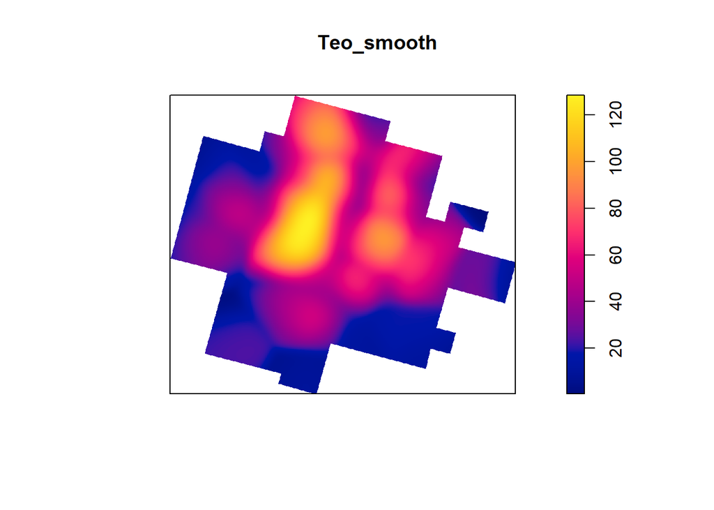

```r
# plot(st_geometry(TMP_MapPoly_sf), pch = 3, col = 'red')
# plot(st_geometry(BufInt), add = TRUE)
BufInt$BufArea <- as.numeric(st_area(BufInt))/10000
BufArea <- BufInt$BufArea
rm(buf, buf_sf, BufInt)
pts_agg <- aggregate(TeoPts_sf, TeoPts_sf, FUN = sum, na.rm = T, join = function(x,
    y) st_is_within_distance(x, y, dist = distm))  #calculate 3km average for all sites
pts_agg$BufArea <- BufArea
pts_agg$RadiusPopDens <- pts_agg$XM_Pop/pts_agg$BufArea
pts_agg_sp = as(pts_agg, Class = "Spatial")

w <- as.owin(TMP_MapPoly)

Teo_ppp <- ppp(x = cents@coords[, 1], y = cents@coords[, 2], window = w, marks = pts_agg$RadiusPopDens)
# plot(Teo_ppp)


Teo_smooth = Smooth.ppp(X = Teo_ppp, sigma = distm, eps = 10, weights = Teo_ppp$marks,
    scalekernel = TRUE)
plot(Teo_smooth)
```

```r
Teo_PopDens = raster(Teo_smooth)
Teo_PopDens = st_as_stars(Teo_PopDens)

RuralOpenPoly_sf = st_as_sf(RuralOpenPoly)
Low_sf = st_as_sf(Teo_ArchPts_Data) %>%
    filter(XM_f == "Low")
IM_sf = st_as_sf(Teo_ArchPts_Data) %>%
    filter(XM_f == "IM")
UncertStat_sf = st_as_sf(Teo_ArchPts_Data) %>%
    filter(XM_f == "UncertStat")
High_sf = st_as_sf(Teo_ArchPts_Data) %>%
    filter(XM_f == "High")
CCFeatPoly_sf = st_as_sf(Teo_ArchPoly_Data) %>%
    filter(XM_group_f == "CCFeat")
AoDPoly_sf = st_as_sf(Teo_ArchPoly_Data) %>%
    filter(XM_group_f == "AoD")
PlazaPoly_sf = st_as_sf(Teo_ArchPoly_Data) %>%
    filter(XM_group_f == "Plaza")
```

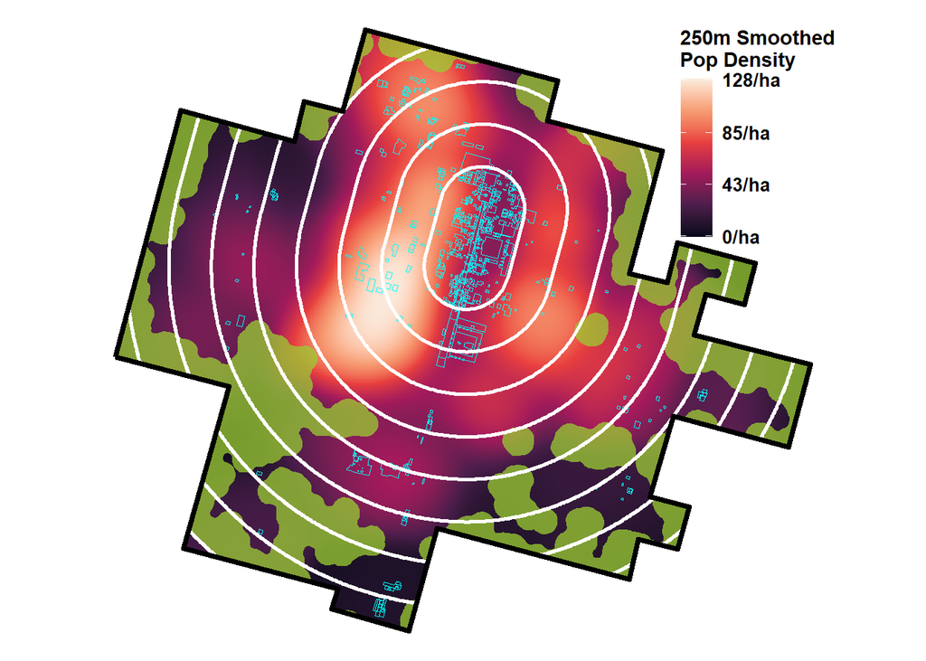

```r
my_breaks <- c(0, 43, 85, floor(max(Teo_smooth$v, na.rm=T)))
  my_labs <- sapply(my_breaks, paste, "/ha", sep="")
  my_breaks[1] <- 1
#plasma inferno cividis viridis     begin = 0.15,
map = ggplot() +geom_stars(data = Teo_PopDens)+
  scale_fill_viridis_c(option = "rocket", na.value = NA,
                       name = paste0(distm,"m Smoothed    \nPop Density    "),
                       breaks = my_breaks, labels = my_labs) +
  geom_sf(data = RuralOpenPoly_sf, fill="yellowgreen", color = NA, size=0, alpha=0.75) +
  geom_sf(data = CCFeatPoly_sf, fill=NA, color = "cyan", size=0.3, alpha=0.2) +
  geom_sf(data = AoDPoly_sf, fill=NA, color = "cyan", size=0.3, alpha=0.2) +
  geom_sf(data = PlazaPoly_sf, fill=NA, color = "cyan", size=0.3, alpha=0.2) +
  #geom_sf(data = Low_sf, color="red", size=0.75) +
  #geom_sf(data = UncertStat_sf, color="magenta", size=0.75) +
  #geom_sf(data = IM_sf, color="yellow", size=0.75) +
  #geom_sf(data = High_sf, color="green", size=0.75) +
  geom_sf(data = RingsPoly_sf, fill=NA, color="white", size=1) +
  geom_sf(data = TMP_MapPoly_sf, fill=NA, color="black", size=1.5) +
  coord_sf(datum = sf::st_crs(32614))+
  theme_void() +
  theme(legend.position = c(0.9,0.8))+#legend.key.width = unit(1, "cm"), legend.key.height = unit(1.6, "cm")
  theme(legend.title = element_text(size=11, face="bold"))+
  theme(legend.text = element_text(size=10, face="bold"))#+
  #theme(legend.title.align=0.5)
map
```

```r
#ggsave("Fig3_PopDens.png", plot = plt, device = "png", path = wd$figs, scale = 1, width = 8, height = 5,   units = "in",  dpi = 1000, bg = "white")

#rm(w,UncertStat_sf,TMP_MapPoly,TMP_MapPoly_sf,TeoPts_sf,Teo_smooth,Teo_ppp,Teo_PopDens,Teo_ArchPts_Data,Teo_ArchPoly_Data,RingsPoly_sf,RingsPoly,pts_agg_sp,pts_agg,PlazaPoly_sf,Low_sf,IM_sf,High_sf,cents,CCFeatPoly_sf,AoDPoly_sf,my_breaks,my_labs,distm,BufArea,RuralOpenPoly_sf)
```

## 2.1 Population Density Falloff Curve

First, we must fit an exponential function to the falloff population density curve. We will fit a simple exponential model taking the form

$D_{i} = \beta_{1} e^{\beta_{2}d_{i}} + \epsilon$

where $D_{i}$ is the population density of the *i*th concentric ring (in persons per hectare), $d_{i}$ is the median distance of the *i*th concentric ring from the central point (in meters), and $\epsilon$ denotes independent and identically distributed (i.d.d.) Gaussian stochastic variability.

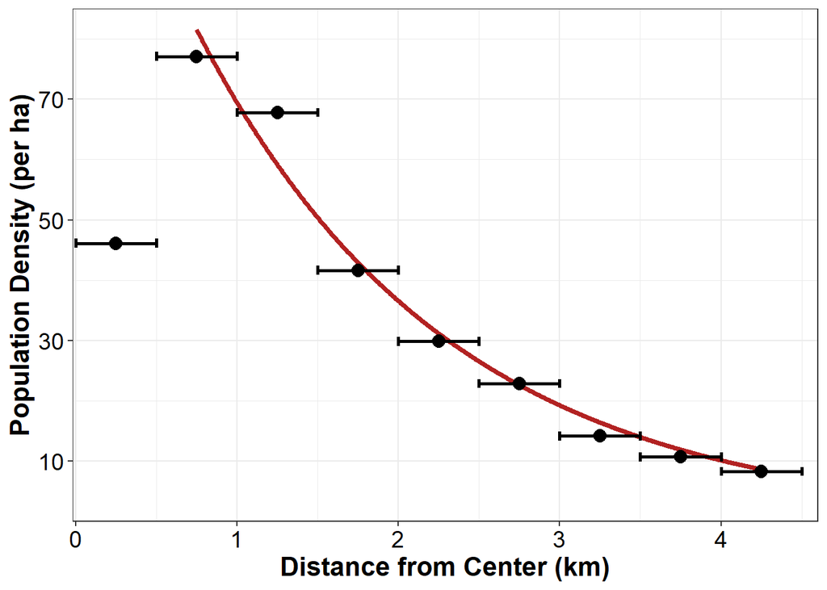

### 2.1.1 Full Regression Results

*“Robust” coef estimates estimated using covariance matrices corrected for heteroskedasticity and autocorrelation*

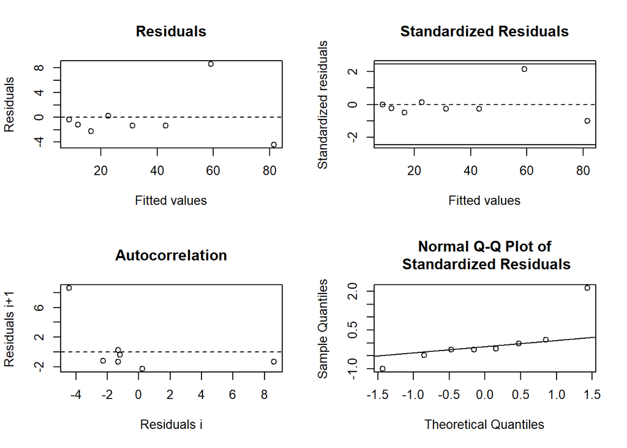

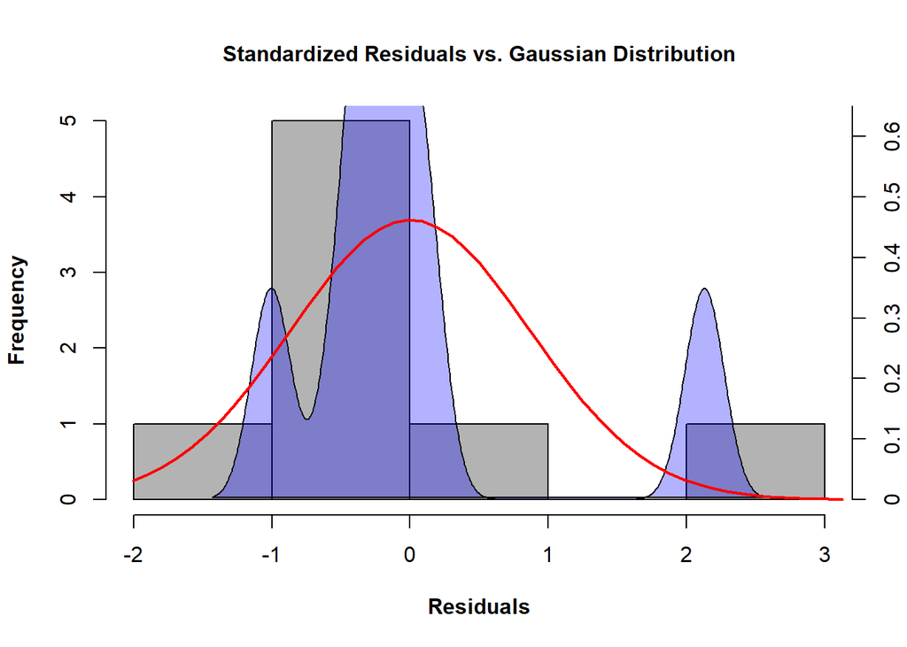

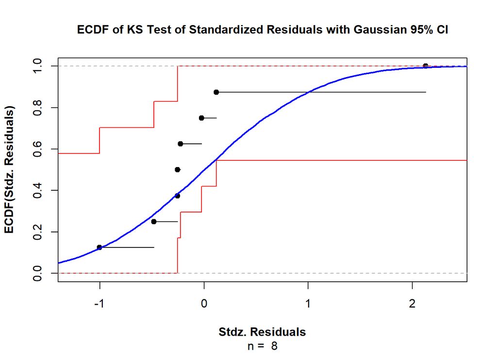

| formula | n | df | R2 | RSS | TSS | resid_se | ConvergToler | ConvergIter |
| --- | --- | --- | --- | --- | --- | --- | --- | --- |
| Popdens_BuiltUp ~ expfunc(MedRingDist, b1, b2) | 8 | 6 | 0.9782956 | 104.0152 | 4792.358 | 4.163637 | 1.490116e-08 | 16 |

| term | estimate | std.error | statistic | p.value | ci0.025 | ci0.975 | EstMethod |
| --- | --- | --- | --- | --- | --- | --- | --- |
| b1 | 131.81787949 | 9.678964e+00 | 13.61901 | 9.730203e-06 | 9.165022e+46 | 3.415245e+67 | standard |
| b2 | -0.00064071 | 5.021191e-05 | -12.76012 | 1.422007e-05 | -7.635742e-04 | -5.178459e-04 | standard |
| b1 | 131.81787949 | 9.849589e+00 | 13.38308 | 1.077423e-05 | 6.036894e+46 | 5.184917e+67 | robust |
| b2 | -0.00064071 | 3.138223e-05 | -20.41633 | 8.977211e-07 | -7.174996e-04 | -5.639205e-04 | robust |

| statistic | p.value | method | alternative |
| --- | --- | --- | --- |
| 0.7581416 | 0.0100453 | Shapiro-Wilk normality test | NA |
| 0.3211058 | 0.3108637 | Exact one-sample Kolmogorov-Smirnov test | two-sided |

## 2.2 Plot Figure 3

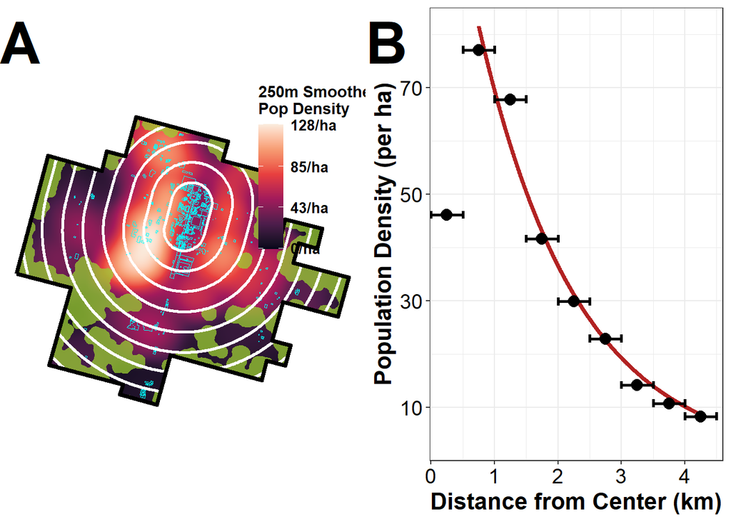

```r
Fig3 <- plot_grid(map, f3b, labels = "AUTO", label_size = 40, hjust = 0)
Fig3
```

```r
ggsave("Fig3.png", plot = Fig3, device = "png", path = wd$figs, scale = 1, width = 12,
    height = 5.5, units = "in", dpi = 1000, bg = "white")

# rm(f3a, f3b, Fig3)
```

# 3 Figure 4

## 3.1 Figure 4A

```r
areas = data.frame("Ring"= TeoRings$Ring, "MedRingDist"= TeoRings$MedRingDist, "DomStruct" = (TeoRings$Area_DStr+TeoRings$DomPlat_Area), "CCFeat" = TeoRings$CCFeat_O_Area, "UrbanOpen" = (TeoRings$Area_UrbanOpen + TeoRings$UnOccuFeat_Area), "RuralOpen" = TeoRings$Area_RuralOpen)
areas = areas %>% pivot_longer(3:6, names_to = "Land_Use", values_to = "Area") %>%
  group_by(Ring, Land_Use) %>%
  summarise(n = sum(Area)) %>%
  mutate(percentage = n / sum(n))
```

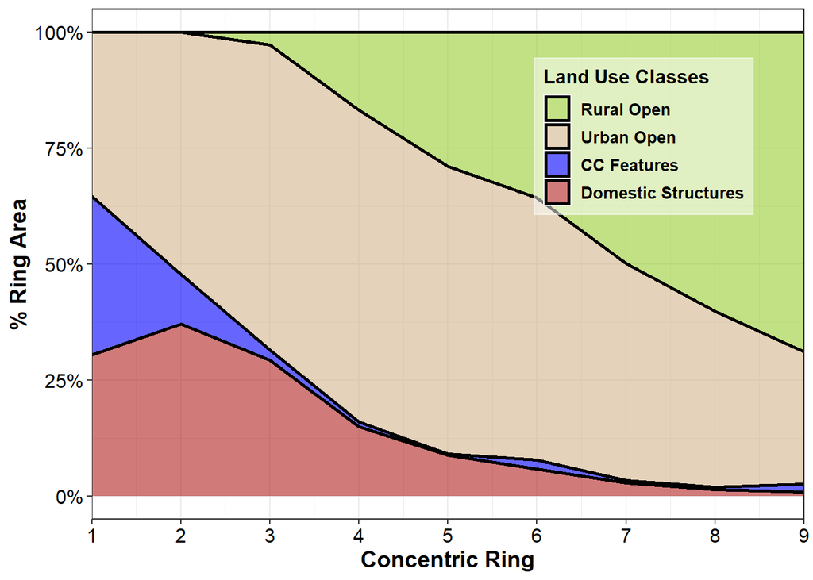

```r
LandUse <- factor(areas$Land_Use, levels = c("RuralOpen", "UrbanOpen", 'CCFeat', 'DomStruct'))

f4a <- ggplot(areas, aes(x=Ring, y=percentage, fill=LandUse)) +
    geom_area(alpha=0.6 , size=1, colour="black",stat="identity")+
  scale_fill_manual(name="Land Use Classes", values = c("yellowgreen","tan","blue","firebrick"),
                    labels=c("Rural Open", "Urban Open", "CC Features", "Domestic Structures"))+
xlab("Concentric Ring") +
  ylab("% Ring Area") +
  theme_bw() +
  scale_y_continuous(labels = scales::percent) +#, limits=c(0,1)expand = c(0, 0), limits=c(0,90),breaks=seq(0,90,10)
  scale_x_continuous(expand = c(0, 0), limits=c(1,9),breaks=seq(1,9,1)) +
  theme(legend.position = c(0.775, 0.75))+
  theme(legend.title = element_text(size=12, face="bold"))+
  theme(legend.text = element_text(size=10, face="bold"))+
  theme(legend.background = element_rect(color=alpha('white', 0.5), fill=alpha('white', 0.5)))+
  theme(axis.text = element_text(size = 12, color="black")) +
  theme(axis.title.y = element_text(size = 14, face = "bold")) +
  theme(axis.title.x = element_text(size = 14, face = "bold"))
f4a
```

## 3.2 Figure 4B

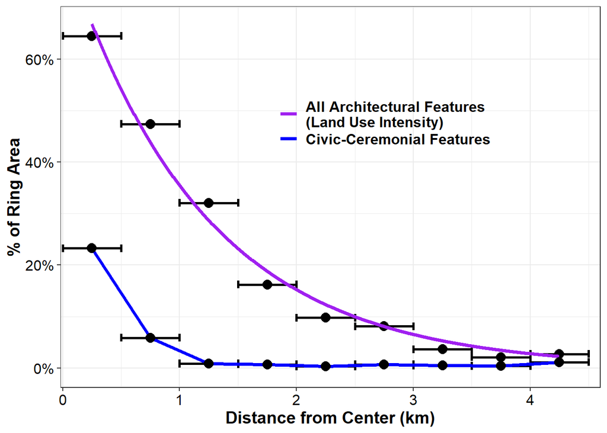

### 3.2.1 Full Regression Results

*“Robust” coef estimates estimated using covariance matrices corrected for heteroskedasticity and autocorrelation*

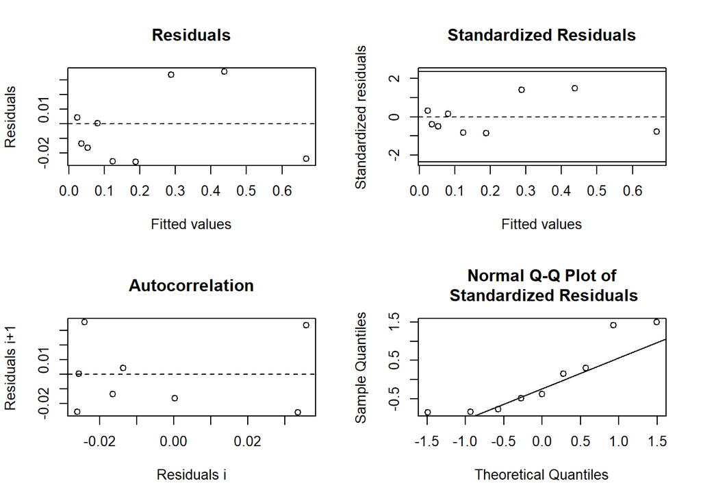

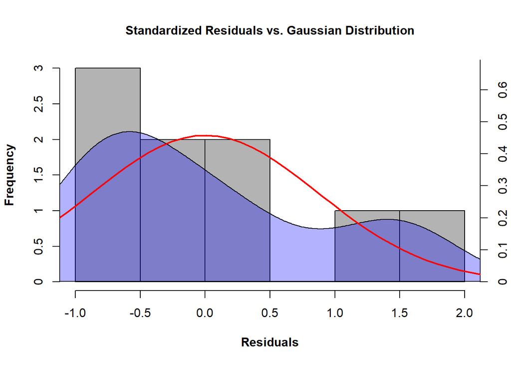

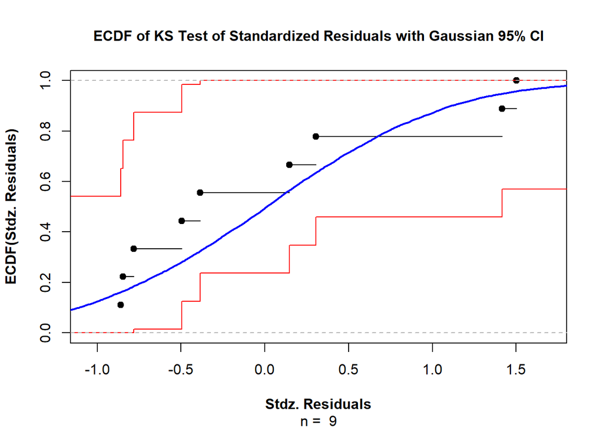

| formula | n | df | R2 | RSS | TSS | resid_se | ConvergToler | ConvergIter |
| --- | --- | --- | --- | --- | --- | --- | --- | --- |
| PctRow_Area_ArchFeat ~ expfunc(MedRingDist, b1, b2) | 9 | 7 | 0.9880686 | 0.004785961 | 0.4011235 | 0.02614782 | 1.490116e-08 | 17 |

| term | estimate | std.error | statistic | p.value | ci0.025 | ci0.975 | EstMethod |
| --- | --- | --- | --- | --- | --- | --- | --- |
| b1 | 0.8255785471 | 3.634523e-02 | 22.71491 | 8.116874e-08 | 2.0951721622 | 2.4881049753 | standard |
| b2 | -0.0008451933 | 5.227109e-05 | -16.16942 | 8.417922e-07 | -0.0009687948 | -0.0007215918 | standard |
| b1 | 0.8255785471 | 3.357695e-02 | 24.58766 | 4.690276e-08 | 2.1089320525 | 2.4718711419 | robust |
| b2 | -0.0008451933 | 4.733942e-05 | -17.85390 | 4.268615e-07 | -0.0009571333 | -0.0007332534 | robust |

| statistic | p.value | method | alternative |
| --- | --- | --- | --- |
| 0.8430213 | 0.06239444 | Shapiro-Wilk normality test | NA |
| 0.2265582 | 0.66550243 | Exact one-sample Kolmogorov-Smirnov test | two-sided |

## 3.3 Figure 4C

```r
areas = data.frame("Ring"= TeoRings$Ring,
                   "High" = TeoRings$Elite_DStrArea,
                   "Intermediate" = TeoRings$IM_DStrArea,
                   "Uncertain" = TeoRings$UncerStat_Area,
                   "Low" = TeoRings$Low_DStrArea)
areas = areas %>% pivot_longer(2:5, names_to = "Status", values_to = "Area") %>%
  group_by(Ring, Status) %>%
  summarise(n = sum(Area)) %>%
  mutate(percentage = n / sum(n))
```

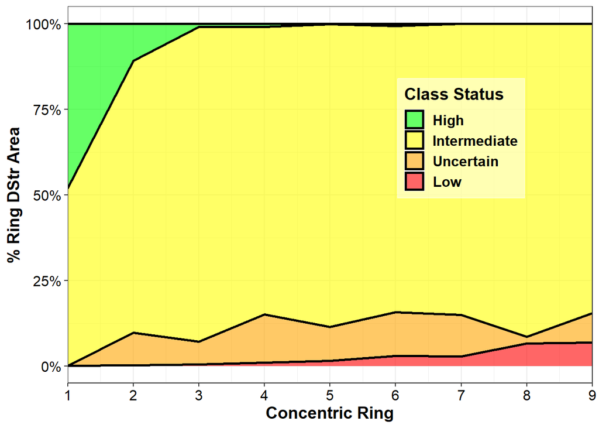

```r
Class <- factor(areas$Status, levels = c('High','Intermediate','Uncertain','Low'))

f4c <- ggplot(areas, aes(x=Ring, y=percentage, fill=Class)) +
    geom_area(alpha=0.6 , size=1, colour="black",stat="identity")+
  scale_fill_manual(name="Class Status",values = c("green","yellow","orange","red"))+
xlab("Concentric Ring") +
  ylab("% Ring DStr Area") +
  theme_bw() +
  scale_y_continuous(labels = scales::percent, limits=c(0,1)) +#expand = c(0, 0), limits=c(0,90),breaks=seq(0,90,10)
  scale_x_continuous(expand = c(0, 0), limits=c(1,9),breaks=seq(1,9,1)) +
  theme(legend.position = c(0.75, 0.65))+
  theme(legend.title = element_text(size=14, face="bold"))+
  theme(legend.text = element_text(size=12, face="bold"))+
  theme(legend.background = element_rect(color=alpha('white', 0.5), fill=alpha('white', 0.5)))+
  theme(axis.text = element_text(size = 12, color="black")) +
  theme(axis.title.y = element_text(size = 14, face = "bold")) +
  theme(axis.title.x = element_text(size = 14, face = "bold"))
f4c
```

## 3.4 Figure 4D

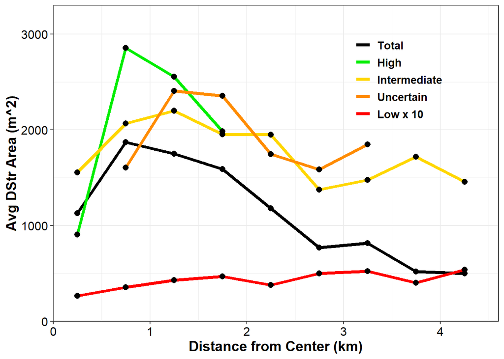

## 3.5 Plot Figure 4

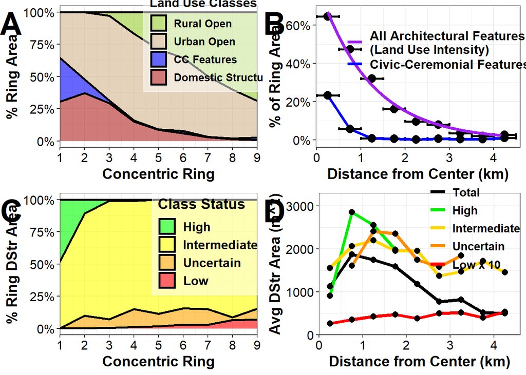

```r
Fig4 <- plot_grid(f4a, f4b, f4c, f4d, labels = "AUTO", label_size = 30, hjust = 0)
# , ncol = 2 label_x = 1, label_y = 1
Fig4
```

```r
ggsave("Fig4.png", plot = Fig4, device = "png", path = wd$figs, scale = 1, width = 10,
    height = 9, units = "in", dpi = 1000, bg = "white")

# rm(f4a, f4b, f4c, f4d, Fig4)
```

# 4 Figure 5

## 4.1 Figure 5A

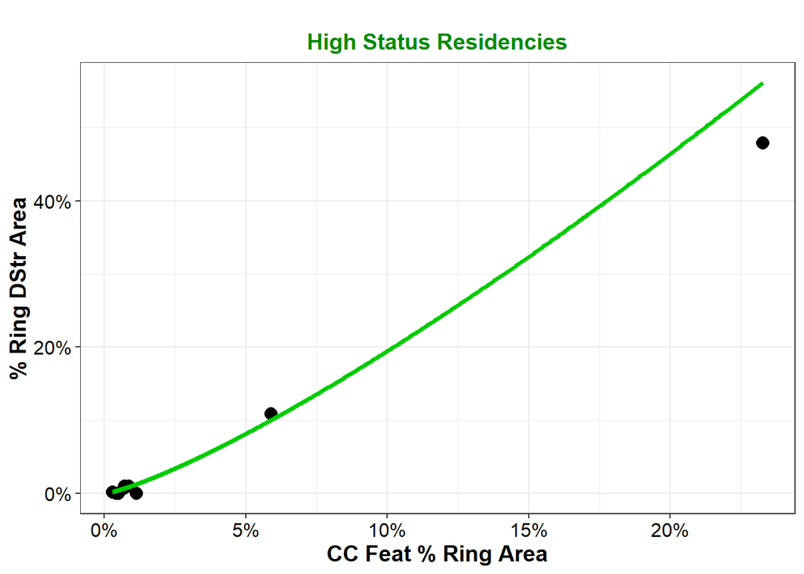

### 4.1.1 Full Regression Results

*“Robust” coef estimates estimated using covariance matrices corrected for heteroskedasticity and autocorrelation*

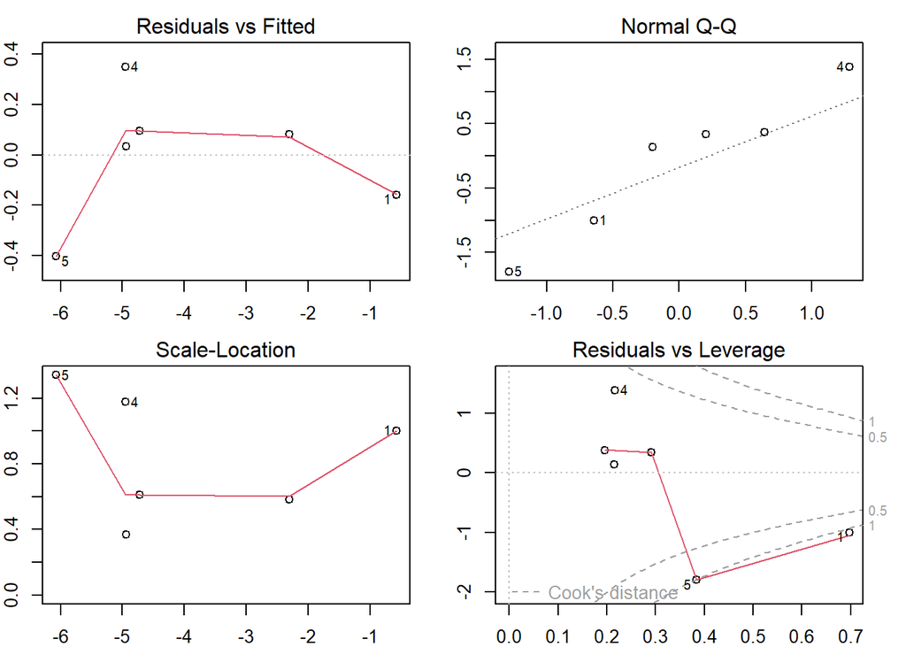

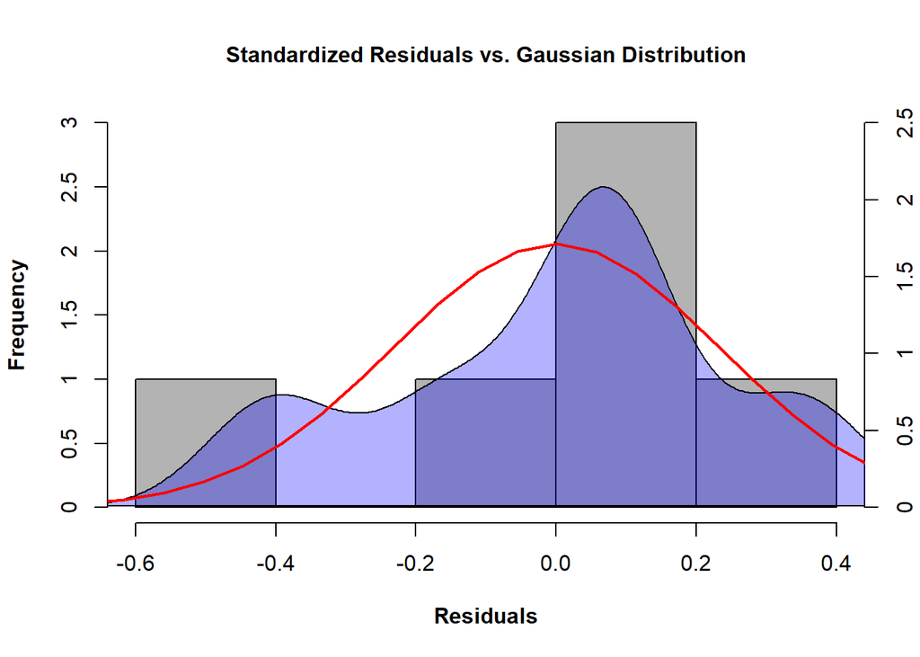

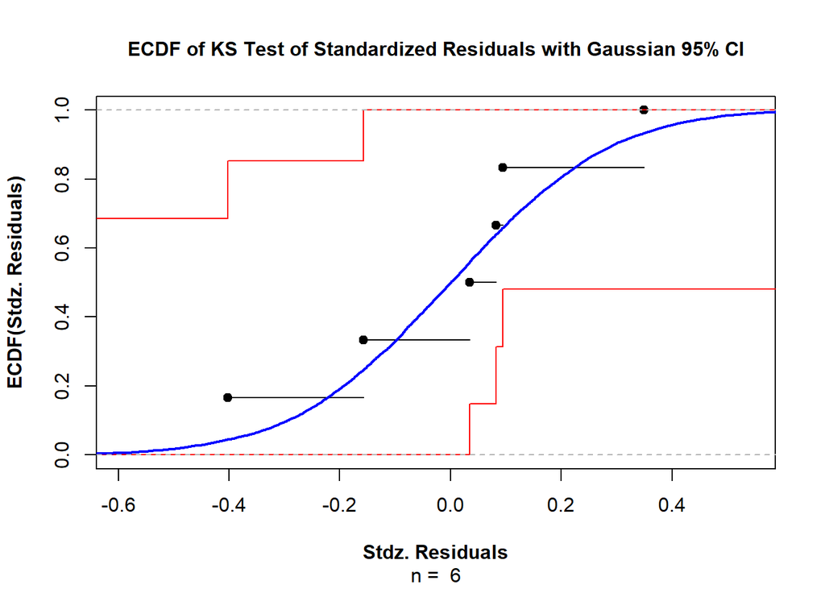

| formula | n | df | R2 | Adj_R2 | resid_se |
| --- | --- | --- | --- | --- | --- |
| Log_PctRow_DStrArea_Elite ~ Log_PctRow_Area_CCFeat_AoD | 6 | 4 | 0.9848321 | 0.9810401 | 0.2851715 |

| term | estimate | std.error | statistic | p.value | ci0.025 | ci0.975 | EstMethod |
| --- | --- | --- | --- | --- | --- | --- | --- |
| (Intercept) | 1.252910 | 0.34169326 | 3.666769 | 2.145204e-02 | 1.355564 | 9.039492 | standard |
| Log_PctRow_Area_CCFeat_AoD | 1.255215 | 0.07788790 | 16.115659 | 8.671464e-05 | 1.038963 | 1.471466 | standard |
| (Intercept) | 1.252910 | 0.21905772 | 5.719544 | 4.623865e-03 | 1.905432 | 6.430885 | robust |
| Log_PctRow_Area_CCFeat_AoD | 1.255215 | 0.06435309 | 19.505121 | 4.073657e-05 | 1.076542 | 1.433888 | robust |

| statistic | p.value | method | alternative |
| --- | --- | --- | --- |
| 0.9574042 | 0.7995283 | Shapiro-Wilk normality test | NA |
| 0.2253305 | 0.8612571 | Exact one-sample Kolmogorov-Smirnov test | two-sided |

## 4.2 Figure 5B

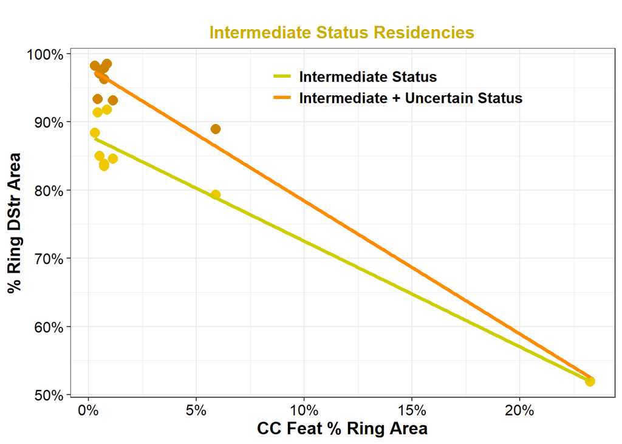

### 4.2.1 Full Regression Results

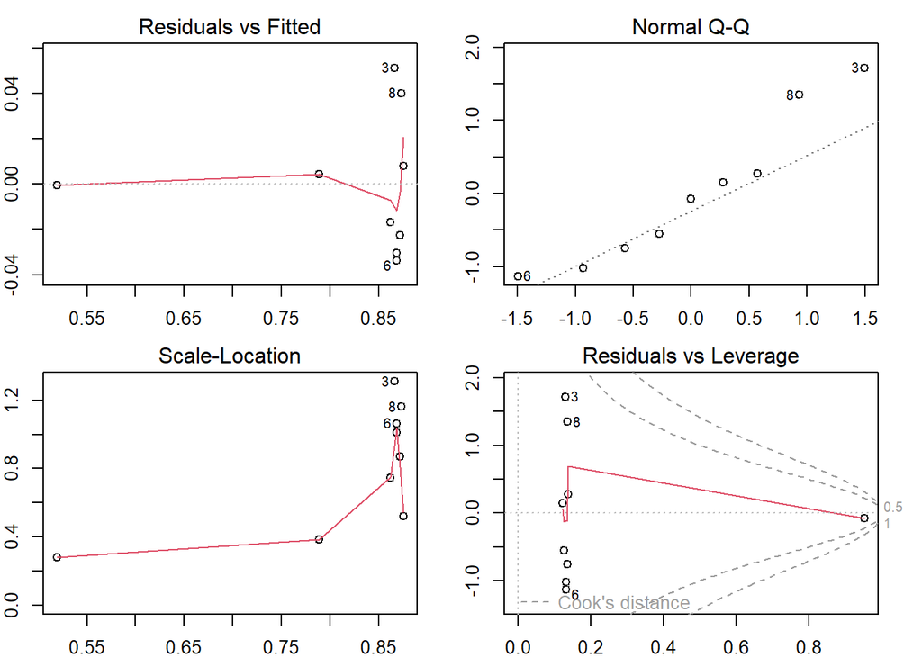

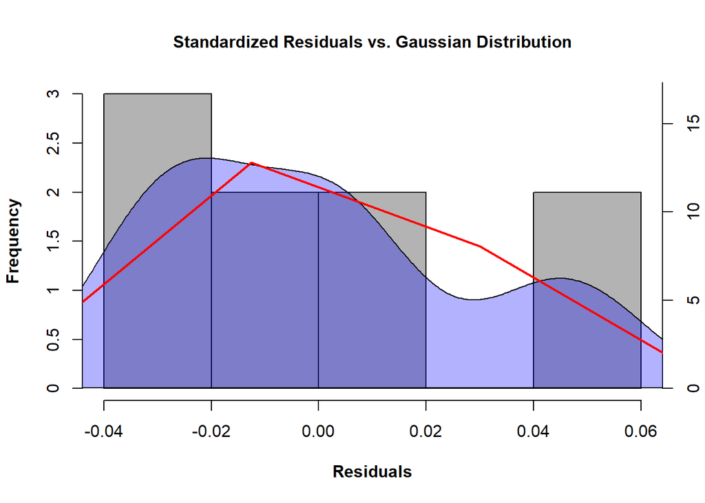

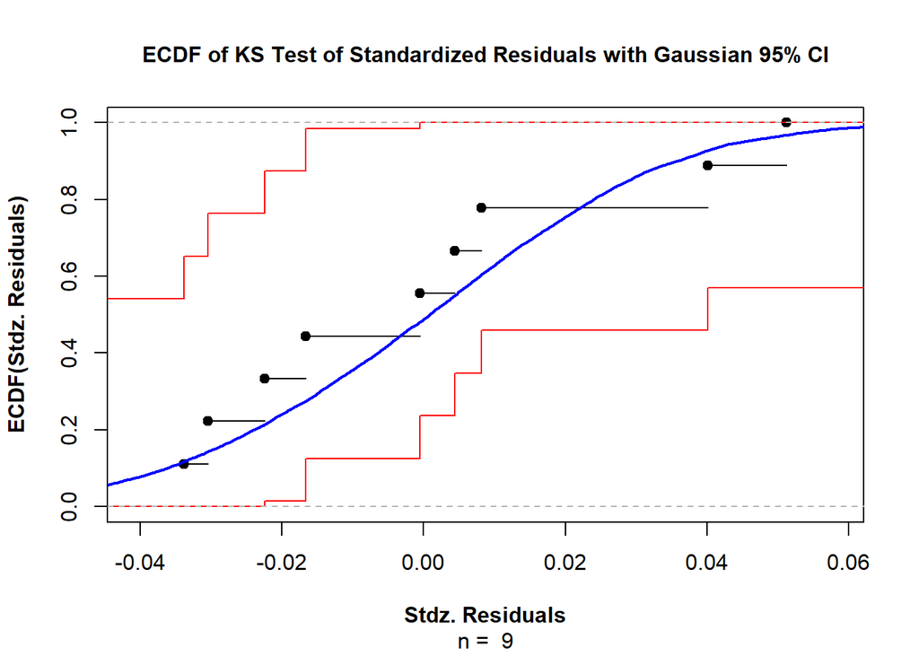

```r
results_f5b1 = RegressionResultsTab(fit_f5b1, TeoRings, TeoRings$PctRow_Area_CCFeat_AoD,
    TeoRings$PctRow_DStrArea_IM, model_type = "ols", coef = "both", residplots = T,
    residhists = T)
```

```r
results_f5b1[[1]]
```

| formula | n | df | R2 | Adj_R2 | resid_se |
| --- | --- | --- | --- | --- | --- |
| PctRow_DStrArea_IM ~ PctRow_Area_CCFeat_AoD | 9 | 7 | 0.937994 | 0.9291359 | 0.03203346 |

```r
results_f5b1[[2]]
```

| term | estimate | std.error | statistic | p.value | ci0.025 | ci0.975 | EstMethod |
| --- | --- | --- | --- | --- | --- | --- | --- |
| (Intercept) | 0.8799928 | 0.01208237 | 72.83278 | 2.419386e-11 | 2.342977 | 2.480755 | standard |
| PctRow_Area_CCFeat_AoD | -1.5493004 | 0.15055793 | -10.29039 | 1.770949e-05 | -1.905313 | -1.193288 | standard |
| (Intercept) | 0.8799928 | 0.01155804 | 76.13682 | 1.774114e-11 | 2.345884 | 2.477681 | robust |
| PctRow_Area_CCFeat_AoD | -1.5493004 | 0.05734844 | -27.01556 | 2.441060e-08 | -1.684908 | -1.413693 | robust |

```r
results_f5b1[[3]]
```

| statistic | p.value | method | alternative |
| --- | --- | --- | --- |
| 0.9149486 | 0.3520617 | Shapiro-Wilk normality test | NA |
| 0.1669642 | 0.9295182 | Exact one-sample Kolmogorov-Smirnov test | two-sided |

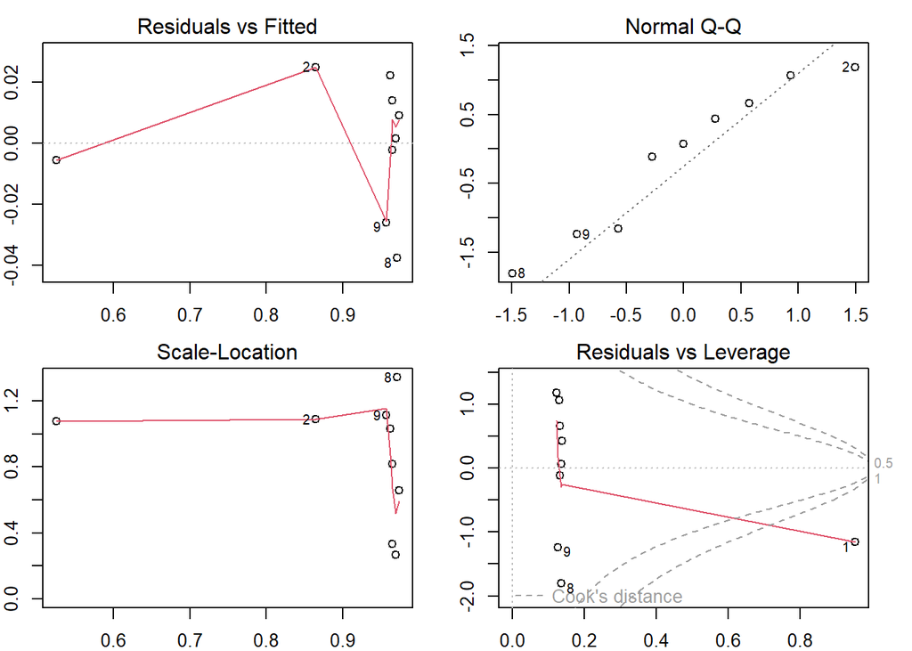

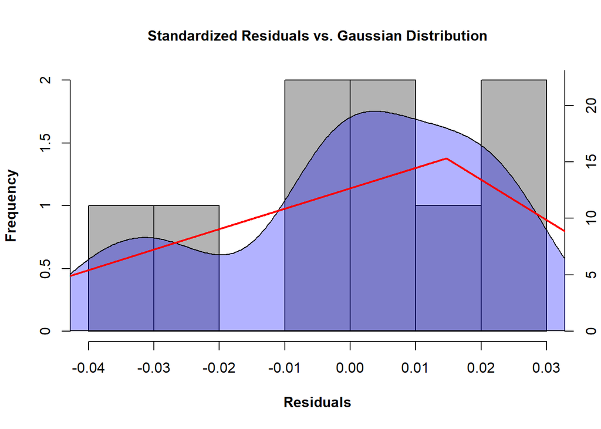

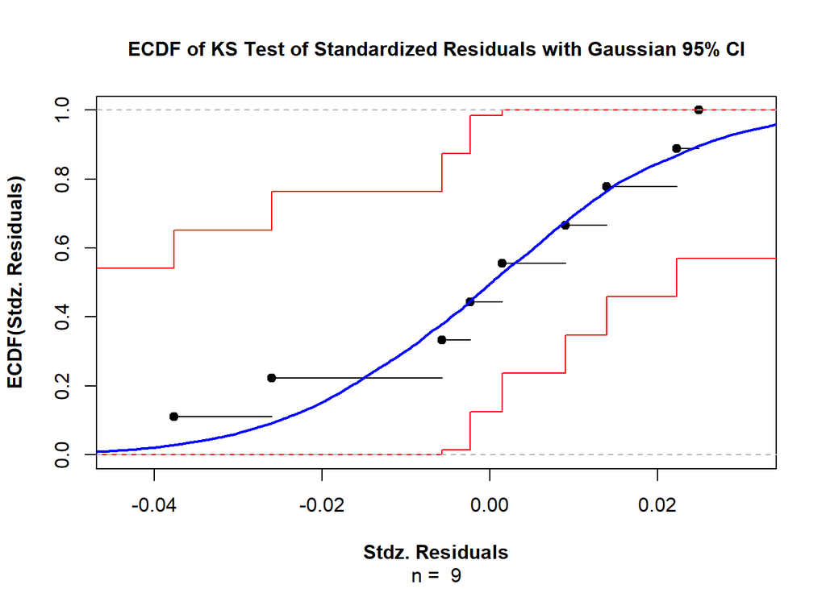

```r
results_f5b2 = RegressionResultsTab(fit_f5b2, TeoRings, TeoRings$PctRow_Area_CCFeat_AoD,
    TeoRings$PctRow_DStrArea_IM, model_type = "ols", coef = "both", residplots = T,
    residhists = T)
```

```r
results_f5b2[[1]]
```

| formula | n | df | R2 | Adj_R2 | resid_se |
| --- | --- | --- | --- | --- | --- |
| PctRow_DStrArea_IMUncerStat ~ PctRow_Area_CCFeat_AoD | 9 | 7 | 0.9799191 | 0.9770504 | 0.02245444 |

```r
results_f5b2[[2]]
```

| term | estimate | std.error | statistic | p.value | ci0.025 | ci0.975 | EstMethod |
| --- | --- | --- | --- | --- | --- | --- | --- |
| (Intercept) | 0.9791591 | 0.008469360 | 115.61194 | 9.551001e-13 | 2.609431 | 2.716070 | standard |
| PctRow_Area_CCFeat_AoD | -1.9505381 | 0.105536329 | -18.48215 | 3.365846e-07 | -2.200092 | -1.700984 | standard |
| (Intercept) | 0.9791591 | 0.007694766 | 127.25001 | 4.881872e-13 | 2.614215 | 2.711100 | robust |
| PctRow_Area_CCFeat_AoD | -1.9505381 | 0.045649208 | -42.72885 | 1.003590e-09 | -2.058481 | -1.842595 | robust |

```r
results_f5b2[[3]]
```

| statistic | p.value | method | alternative |
| --- | --- | --- | --- |
| 0.9362033 | 0.5425490 | Shapiro-Wilk normality test | NA |
| 0.1645073 | 0.9365716 | Exact one-sample Kolmogorov-Smirnov test | two-sided |

## 4.3 Figure 5C

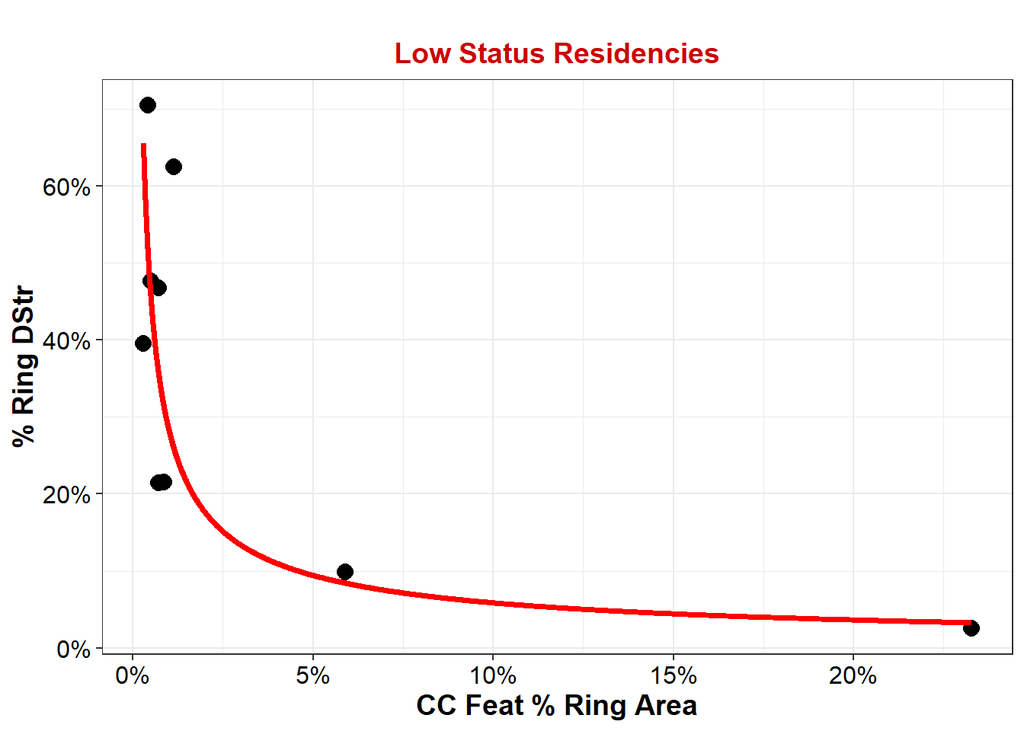

### 4.3.1 Full Regression Results

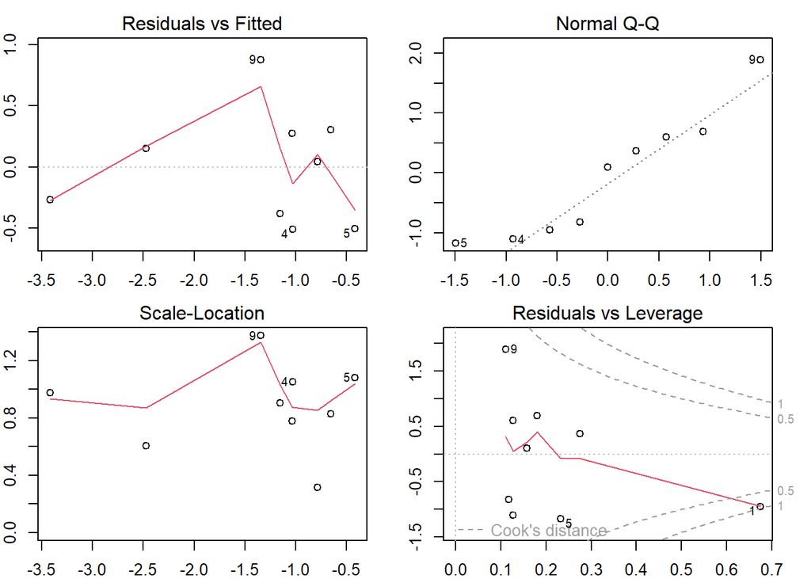

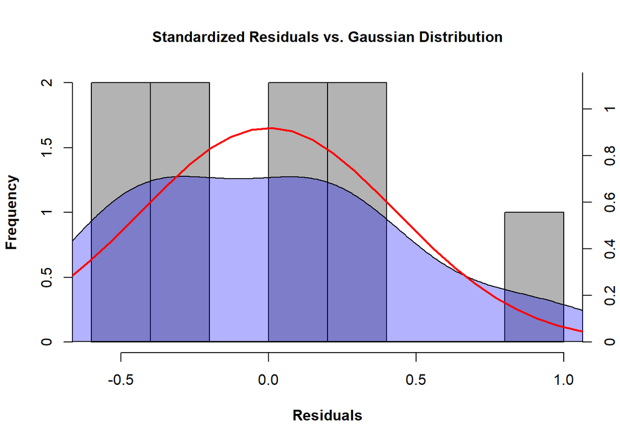

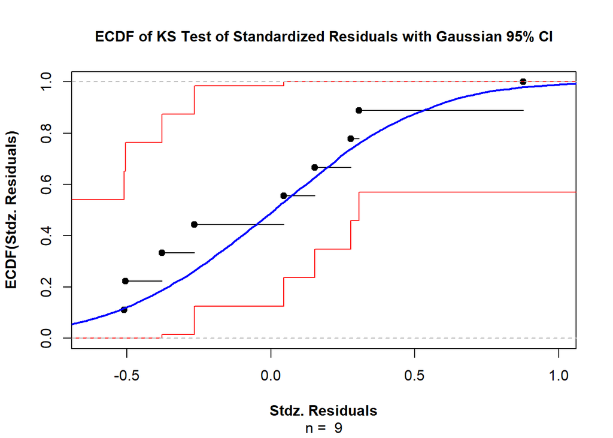

```r
results_f5c = RegressionResultsTab(fit_f5c, TeoRings, TeoRings$Log_PctRow_Area_CCFeat_AoD,
    TeoRings$Log_PctRow_Ring_DStr_Low, model_type = "ols", coef = "both", residplots = T,
    residhists = T)
```

```r
results_f5c[[1]]
```

| formula | n | df | R2 | Adj_R2 | resid_se |
| --- | --- | --- | --- | --- | --- |
| Log_PctRow_Ring_DStr_Low ~ Log_PctRow_Area_CCFeat_AoD | 9 | 7 | 0.8137675 | 0.7871629 | 0.4921018 |

```r
results_f5c[[2]]
```

| term | estimate | std.error | statistic | p.value | ci0.025 | ci0.975 | EstMethod |
| --- | --- | --- | --- | --- | --- | --- | --- |
| (Intercept) | -4.4095515 | 0.57365381 | -7.686782 | 1.175207e-04 | 0.003132176 | 0.04721348 | standard |
| Log_PctRow_Area_CCFeat_AoD | -0.6838544 | 0.12364944 | -5.530590 | 8.776883e-04 | -0.976238870 | -0.39146992 | standard |
| (Intercept) | -4.4095515 | 0.32046619 | -13.759803 | 2.525915e-06 | 0.005699746 | 0.02594518 | robust |
| Log_PctRow_Area_CCFeat_AoD | -0.6838544 | 0.07429211 | -9.204939 | 3.683750e-05 | -0.859527330 | -0.50818146 | robust |

```r
results_f5c[[3]]
```

| statistic | p.value | method | alternative |
| --- | --- | --- | --- |
| 0.9207661 | 0.3986206 | Shapiro-Wilk normality test | NA |
| 0.1748034 | 0.9042522 | Exact one-sample Kolmogorov-Smirnov test | two-sided |